# lab1_combettes

**X-HEC Data Science for Business MSc&T - Python for Data Science - 2022/2023**

Contacts:

- Mathurin Massias mathurin.massias@gmail.com (or use Slack)
- Sylvain Combettes sylvain.combettes8@gmail.com (or use Slack)
- Vincent Maladiere vincent.maladiere@gmail.com (or use Slack)

Lab 1 - Introduction: Python, Numpy, Pandas

**READ ME**

- This is the correction.

```python
import string
from math import pi
from collections import Counter

import numpy as np
import time
import datetime
import math
import pprint

import matplotlib.pyplot as plt
```

# Some preleminary remarks

## Printing

### Return to line and tabs

Return to line with `\n`:

```python
s1 = "line1\nline2"
print(s1)
```

```
line1
line2
```

Add a tab with `\t`:

```python
s = "word1\tword2"
print(s)
```

```
word1	word2
```

Return to line and tab:

```python
result = 2+1
s = f"The result is:\n\t{result}"
print(s)
```

```
The result is:
	3
```

### Printing long strings

```python
first_string = "s1"
second_string = "s2"
third_string = "s3"
fourth_string = "s4"

# Not recommended:
print(f"The first string is {first_string}, the second string is {second_string}, the third string is {third_string}, and the fourth string is {fourth_string}.")

# Recommended:
print(
    f"The first string is {first_string}, the second string is {second_string},"
    f" the third string is {third_string}, and the fourth string is {fourth_string}." # do no forget the space between two lines
)

print(
    f"The first string is {first_string}, the second string is {second_string},"
    f"the third string is {third_string}, and the fourth string is {fourth_string}." # when forgetting the spacing between two lines
)
```

```
The first string is s1, the second string is s2, the third string is s3, and the fourth string is s4.
The first string is s1, the second string is s2, the third string is s3, and the fourth string is s4.
The first string is s1, the second string is s2,the third string is s3, and the fourth string is s4.
```

## General Python conventions

### Strings

```python
s = "hello"
print(s.capitalize())
print(s.upper())
print(s.rjust(10))
print(s.center(10))
print(s.replace('l', '(ell)'))
print('  world '.strip())
```

```
Hello
HELLO
     hello
  hello
he(ell)(ell)o
world
```

### Python indexes

Python indexes start at 0:

```python
for i in range(5):
    print(i)
```

```
0
1
2
3
4
```

```python
for i in range(1, 5):
    print(i)
```

```
1
2
3
4
```

```python
for i in range(0, 5+1):
    print(i)
```

```
0
1
2
3
4
5
```

```python
print(f"{np.arange(5) = }")
print(f"{len(np.arange(5)) = }")
```

```
np.arange(5) = array([0, 1, 2, 3, 4])
len(np.arange(5)) = 5
```

### Python dictionaries

```python
d = dict() # or d = {}
d["jacques"] = 12
d["alain"] = 15
print(d)
```

```
{'jacques': 12, 'alain': 15}
```

```python
import collections

sorted_dic = dict(collections.OrderedDict(sorted(d.items())))
print(sorted_dic)
```

```
{'alain': 15, 'jacques': 12}
```

```python
set_tmp = {1, 2, 3}
print(set_tmp)
print(type(set_tmp))
```

```
{1, 2, 3}
<class 'set'>
```

## Others

```python
# an array is a kind of a list of lists
print(np.array([[1, 2], [3, 4]]))
```

```
[[1 2]
 [3 4]]
```

```python
count = 0
for i in range(10):
    count += 1 # count = count+1
    print(count)
```

```
1
2
3
4
5
6
7
8
9
10
```

# Strings

## Question 1

```python
alphabet_string = string.ascii_lowercase
print(alphabet_string)
print(alphabet_string[2:26:3])
print(alphabet_string[21:26:2])
print(alphabet_string[26:18:-2])
```

```
abcdefghijklmnopqrstuvwxyz
cfilorux
vxz
zxvt
```

```python
start = alphabet_string.index('c')
end = alphabet_string.index('x') + 1
print(alphabet_string[start:end:3])
```

```
cfilorux
```

## Question 2

```python
s = " XHEC DataScience for Business " # copy-pasted from the PDF
print(s)
print(s.lower())
print(s.lower().strip())
print(s.lower().strip().replace("e", "E"))
```

```
 XHEC DataScience for Business
 xhec datascience for business
xhec datascience for business
xhEc datasciEncE for businEss
```

## Question 3

```python
# do not cast to string
str(pi)[:2+9]
```

```
'3.141592653'
```

```python
print(pi)
print("{:.9f}".format(pi))  # %f represents a floating point real number
print(f"{pi:.9f}")
print("%.9f" % pi )
```

```
3.141592653589793
3.141592654
3.141592654
3.141592654
```

## Question 4

```python
s = "HelLo WorLd!!"
print(s)
```

```
HelLo WorLd!!
```

```python
# Version 1: using collections.Counter (forbidden to use for this exercise!)
print(dict(Counter(s.lower())))
```

```
{'h': 1, 'e': 1, 'l': 3, 'o': 2, ' ': 1, 'w': 1, 'r': 1, 'd': 1, '!': 2}
```

```python
# Version 2: using the `count` method

def count_occurences_v2(string : str):
    lower_string = string.lower()
    dict_counter = dict()
    for character in lower_string:
        dict_counter[character] = lower_string.count(character)
    return dict_counter

dict_counter_v2 = count_occurences_v2(s)
print(dict_counter_v2)
```

```
{'h': 1, 'e': 1, 'l': 3, 'o': 2, ' ': 1, 'w': 1, 'r': 1, 'd': 1, '!': 2}
```

```python
# Version 3: from scratch

def count_occurences(string : str):
    lower_string = string.lower()
    dict_counter = dict()
    for character in lower_string:
        if character in dict_counter:
            dict_counter[character] += 1
        else:
            dict_counter[character] = 1
    return dict_counter

dict_counter = count_occurences(s)
print(dict_counter)
```

```
{'h': 1, 'e': 1, 'l': 3, 'o': 2, ' ': 1, 'w': 1, 'r': 1, 'd': 1, '!': 2}
```

Note that using the `count` method makes version 2 slower than version 3, because in `lower_string.count(character)`, the `count` method goes over the whole `lower_string` string so it has a quadratic cost.

```
s = "HelLo WorLd!!"
counter = {}

for letter in s.lower():
    counter[letter] = counter.get(letter, 0) + 1

# The 'O' in the get creates an entry when a new letter is counted
# and the value 0 is assigned to this entry

print(counter)

# Outputs a dictionary that associates to each character the number
# of occurences in the string s
```

# Fast computations with numpy ; basic plots.

## Question 5

```python
print(0.1 + 100 - 100)
print(0.1 + 100 - 100 == 0.1)
```

```
0.09999999999999432
False
```

```python
print('%.25f' % 0.1)
```

```
0.1000000000000000055511151
```

TODO:

print(f"La différence relative est de {np.format_float_scientific(abs(100 * (((0.1 + 100 - 100) - 0.1)/0.1)), precision=3)} %")

check np.isclose

We see that both values are not stored as exactly equal to 0.1 according to python.

That is because floating-point numbers are represented in computer hardware as base 2 (binary) fractions. In other words, 0.1 gets converted from base 10 to base 2, where it is written as 0.000110011…(0011).

Unfortunately the resulting binary number may not accurately represent the original base 10 number. 0.1 is one example.

A consequence is that, in general, the decimal floating-point numbers we enter are only approximated by the binary floating-point numbers actually stored in the machine.

```
result_number2 = np.float32(0.1 + 100 - 100)
comparison2 = (result_number2 == np.float32(0.1))
print(comparison2)
```

```python
print(np.allclose(0.1 + 100 - 100, 0.1))
```

```
True
```

TODO: look into the numpy tolerance with np.allclose

The order of operations matters, because by default Python actually computes `(0.1 + 100) - 100` for `0.1 + 100 - 100`, when the human eye would do the following:

```python
print(0.1 + (100 - 100))
print(0.1 + (100 - 100) == 0.1)
```

```
0.1
True
```

## Question 6

Using a for-loop:

```python
l = list()
for i in range(1, 11+1):
    l.append(i**2)
print(l)
```

```
[1, 4, 9, 16, 25, 36, 49, 64, 81, 100, 121]
```

The following numpy versions are equivalent, but the last one is more concise:

```python
print(np.power(np.arange(1, 11+1), 2))
```

```
[  1   4   9  16  25  36  49  64  81 100 121]
```

```python
print(np.square(np.arange(1, 11+1)))
```

```
[  1   4   9  16  25  36  49  64  81 100 121]
```

```python
print(np.arange(1, 11+1)**2)
```

```
[  1   4   9  16  25  36  49  64  81 100 121]
```

*Note:* `np.arange(1, 11+1)` is kind of a novice way to emphasize that it will end at 11 included, it would be better to write `np.arange(1, 12)` directly, as experienced users know that 12 will be excluded and 11 is the last included value.

## Question 7

```python
np.arange(start=2, stop=14+1, step=3)
```

```
array([ 2,  5,  8, 11, 14])
```

```python
np.linspace(start=0, stop=1, num=15)
```

```
array([0.        , 0.07142857, 0.14285714, 0.21428571, 0.28571429,
       0.35714286, 0.42857143, 0.5       , 0.57142857, 0.64285714,
       0.71428571, 0.78571429, 0.85714286, 0.92857143, 1.        ])
```

*Note*: We can set the precision of the way floating point numbers, arrays and other NumPy objects (and them only) are displayed:

```python
np.set_printoptions(precision=3)  # better to up it at the top of the notebook
```

```python
print(np.linspace(start=0, stop=1, num=15))
```

```
[0.    0.071 0.143 0.214 0.286 0.357 0.429 0.5   0.571 0.643 0.714 0.786
 0.857 0.929 1.   ]
```

```python
print(math.pi)
```

```
3.141592653589793
```

## Question 8

```python
n = int(1e6) # better than writing `n = 100000` because we can make typos regarding the number of zeros
print(n)
```

```
1000000
```

```python
n = 1_000_000 # better than writing `n = 100000` because we can make typos regarding the number of zeros
print(n)
```

```
1000000
```

```python
def forloop_prod(n):
    prod_loop = 2 # initilization, do not forget the 2 in factor and the final product
    for k in range(1, n+1):
        elem = (4*k**2) / (4*k**2-1)
        prod_loop *= elem
    return prod_loop
```

The above code is better, in some sense, than:

```
def forloop_prod(n):
    prod_loop = 1
    for k in range(1, n+1):
        elem = (4*k**2) / (4*k**2-1)
        prod_loop *= elem
    return 2*prod_loop
```

```python
start_time = time.time()

prod_loop = forloop_prod(n)
print(prod_loop)

end_time = time.time()
print(str(datetime.timedelta(seconds=end_time-start_time)))
```

```
3.141591868192149
0:00:00.635047
```

```python
# Correct, but not concise:
def numpy_prod_naive(n):
    return 2 * np.prod(np.divide(4*np.square(np.arange(1, n+1)), (4*np.square(np.arange(1, n+1))-1)))

# More concise and clearer for the human eye to read:
def numpy_prod(n):
    return 2 * np.prod(4*np.arange(1, n+1)**2 / (4*np.arange(1, n+1)**2-1))
```

```python
start_time = time.time()

prod_numpy = numpy_prod(n)
print(prod_numpy)

end_time = time.time()
print(str(datetime.timedelta(seconds=end_time-start_time)))
```

```
3.141591868192149
0:00:00.030303
```

*Note*: We observe that the result is close to $\pi$.

Using numpy is much faster than the for-loop. More generally, one must always try to use numpy rather than for-loops (in the case of numerical computation). Of course, sometimes, you must use for-loops which are a great tool.

For `time.time()`, the epoch is the point where the time starts, and is platform dependent. For Unix, the epoch is January 1, 1970, 00:00:00 (UTC). The term seconds since the epoch refers to the total number of elapsed seconds since the epoch. Hence, the duration of running some lines of code is the difference between times.

Note that we set a variable `n` at the beginning of both for-loop and numpy version, so that:

- we are sure to use the same value of `n` for both versions
- it is easy to change the value of `n` and run computations again

Indeed, the following code:

```python
2 * np.prod((4 * np.arange(1, 100000)**2) / ((4 * np.arange(1, 100000)**2 - 1)))
```

```
3.141584799578707
```

is not distinsguigable from:

```python
2 * np.prod((4 * np.arange(1, 10000)**2) / ((4 * np.arange(1, 10000)**2 - 1)))
```

```
3.1415141108281714
```

while the value of `n` is different between both code lines.

Do we get the exact same result for both for-loop and numpy versions?

```python
np.allclose(prod_loop, prod_numpy)
```

```
True
```

`%time` is a magic line while `%%time` is a magic cell:

```python
%timeit numpy_prod(10_000)
%timeit numpy_prod(100_000)
```

```
55.7 µs ± 1.46 µs per loop (mean ± std. dev. of 7 runs, 10,000 loops each)
405 µs ± 4.51 µs per loop (mean ± std. dev. of 7 runs, 1,000 loops each)
```

```python
%%timeit

numpy_prod(100_00)
numpy_prod(100_000)
```

```
460 µs ± 1.47 µs per loop (mean ± std. dev. of 7 runs, 1,000 loops each)
```

Do not put comments before the magic cell:

```python
# comment
%%timeit

prod_numpy = numpy_prod(n)
```

```
UsageError: Line magic function `%%timeit` not found.
```

```python
%%timeit

prod_numpy = numpy_prod(n)
```

```
4.09 ms ± 24.6 µs per loop (mean ± std. dev. of 7 runs, 100 loops each)
```

`%timeit` outputs, for example, `57.7 ms ± 818 µs per loop (mean ± std. dev. of 7 runs, 10 loops each)`, so several runs are made so that the duration is more robust.

Beware that the different runs are actually executed:

```python
l_iter = list()
print(f"{len(l_iter) = }")
```

```
len(l_iter) = 0
```

```python
%timeit l_iter.append(1)
```

```
47.2 ns ± 0.303 ns per loop (mean ± std. dev. of 7 runs, 10,000,000 loops each)
```

```python
print(f"{len(l_iter) = }")
```

```
len(l_iter) = 81111111
```

Note that when computing the product for large values of `n`, there can be integer overflows. Indeed, in previous versions of numpy, the type of `numpy.arange` by default was`int32`, while now it is `int64`. We can more easily obtain integer overflows with `int32`:

```python
a = np.arange(1, 100_000).astype(np.int32)
print((a ** 2).min())
```

```
-2147479015
```

```python
a = np.arange(1, 100_000).astype(np.int64)
print((a ** 2).min())
```

```
1
```

## Question 9

```python
print(np.arange(5))
print(np.ones(5))
print(np.dot(np.arange(5), np.ones(5)))
```

```
[0 1 2 3 4]
[1. 1. 1. 1. 1.]
10.0
```

```python
print(np.arange(5))
print(np.shape(np.arange(5))) # one possible syntax
print(np.arange(5).shape) # another possible syntax
```

```
[0 1 2 3 4]
(5,)
(5,)
```

```python
print(np.arange(5).T)
print(np.shape(np.arange(5).T))
```

```
[0 1 2 3 4]
(5,)
```

Surprisingly, `np.arange(5).T` has the same shape as `np.arange(5)`, because numpy considers row vectors to be the same as column vectors. Transposing 1D-arrays does nothing.

Be careful that the following is not a numpy 1D-array:

```python
M = np.arange(5).reshape(5, 1)
print(f"{M = }")
print(f"{np.shape(M) = }")
print(f"{np.shape(M.T) = }")
```

```
M = array([[0],
       [1],
       [2],
       [3],
       [4]])
np.shape(M) = (5, 1)
np.shape(M.T) = (1, 5)
```

Note that `np.arange(5).T` works exactly the same as `np.transpose(np.arange(5))` for 2D-arrays, but `np.transpose` is more general because it allows choosing the axis. However:

```python
A = np.ones([5, 3])
B = A.T  # B is not A, but B shares A's data
B[0, :] = 0  # change the first line of B
print(A)  # the first column of A has changed
```

```
[[0. 1. 1.]
 [0. 1. 1.]
 [0. 1. 1.]
 [0. 1. 1.]
 [0. 1. 1.]]
```

More info [here](https://github.com/pierreablin/python-sessions/blob/master/Reference_arrays_args.ipynb).

## Question 10

`reshape` works row by row for the obtained array:

```python
print(f"{np.arange(12) = }")
print(f"{np.shape(np.arange(12)) = }")

M = np.arange(12).reshape(2, 6)
print(f"\n{M = }")
print(f"{np.shape(M) = }")
```

```
np.arange(12) = array([ 0,  1,  2,  3,  4,  5,  6,  7,  8,  9, 10, 11])
np.shape(np.arange(12)) = (12,)

M = array([[ 0,  1,  2,  3,  4,  5],
       [ 6,  7,  8,  9, 10, 11]])
np.shape(M) = (2, 6)
```

```python
M_hat = M.reshape(12,)
print(f"\n{M_hat = }")
print(f"{np.shape(M_hat) = }")
```

```
M_hat = array([ 0,  1,  2,  3,  4,  5,  6,  7,  8,  9, 10, 11])
np.shape(M_hat) = (12,)
```

`M[:, ::3]` keeps all rows of `M`, but selects the columns of `M` with a step of 3 (starting at the column of index 0 and finishing at the last one):

```python
print(M[:, ::3])
print(M[:, 0:-1:3])
```

```
[[0 3]
 [6 9]]
[[0 3]
 [6 9]]
```

```python
a = np.arange(3)
b = np.arange(4)
c = a * b[:, None]
print(f"{c = }")
#print(a * b)
print(f"{a.shape = }")
print(f"{b.shape = }")
print(f"{c.shape = }")
```

```
c = array([[0, 0, 0],
       [0, 1, 2],
       [0, 2, 4],
       [0, 3, 6]])
a.shape = (3,)
b.shape = (4,)
c.shape = (4, 3)
```

*Note*: The `numpy.newaxis` attribute is an alias for `None`:

```python
array = np.arange(3)
print(array.shape)

array = array[:, np.newaxis]
print(array.shape)
```

```
(3,)
(3, 1)
```

## Question 11

Using `numpy.random.rand`:

```python
np.random.seed(0)
a = -1
b = 1
M = (b - a) * np.random.rand(5,6) + a
print(M)
```

```
[[ 0.098  0.43   0.206  0.09  -0.153  0.292]
 [-0.125  0.784  0.927 -0.233  0.583  0.058]
 [ 0.136  0.851 -0.858 -0.826 -0.96   0.665]
 [ 0.556  0.74   0.957  0.598 -0.077  0.561]
 [-0.763  0.28  -0.713  0.889  0.044 -0.171]]
```

Using `numpy.random.uniform`:

```python
np.random.seed(0)
M = np.random.uniform(low=-1, high=1, size=(5, 6))
print(M)
```

```
[[ 0.098  0.43   0.206  0.09  -0.153  0.292]
 [-0.125  0.784  0.927 -0.233  0.583  0.058]
 [ 0.136  0.851 -0.858 -0.826 -0.96   0.665]
 [ 0.556  0.74   0.957  0.598 -0.077  0.561]
 [-0.763  0.28  -0.713  0.889  0.044 -0.171]]
```

```python
print("Even columns:\n",M[:, ::2])
print("Uneven columns:\n",M[:, 1::2])
M_copy = M.copy()
M_copy[:, ::2] = M_copy[:, ::2] - 2*M_copy[:, 1::2]  # touch only the even columns of the matrix
print("Result:\n",M_copy)
```

```
Even columns:
 [[ 0.098  0.206 -0.153]
 [-0.125  0.927  0.583]
 [ 0.136 -0.858 -0.96 ]
 [ 0.556  0.957 -0.077]
 [-0.763 -0.713  0.044]]
Uneven columns:
 [[ 0.43   0.09   0.292]
 [ 0.784 -0.233  0.058]
 [ 0.851 -0.826  0.665]
 [ 0.74   0.598  0.561]
 [ 0.28   0.889 -0.171]]
Result:
 [[-0.763  0.43   0.026  0.09  -0.736  0.292]
 [-1.692  0.784  1.394 -0.233  0.468  0.058]
 [-1.566  0.851  0.794 -0.826 -2.29   0.665]
 [-0.924  0.74  -0.239  0.598 -1.199  0.561]
 [-1.323  0.28  -2.492  0.889  0.385 -0.171]]
```

The random seed will generate a very long imaginary sequence of numbers that will be successively called:

```python
np.random.seed(0)
print(np.random.rand(4))
print(np.random.rand(4))
```

```
[0.549 0.715 0.603 0.545]
[0.424 0.646 0.438 0.892]
```

It can be called again to re-seed the generator:

```python
np.random.seed(0)
print(np.random.rand(8))
```

```
[0.549 0.715 0.603 0.545 0.424 0.646 0.438 0.892]
```

```python
np.random.seed(0)
print(np.random.rand(4, 2))
```

```
[[0.549 0.715]
 [0.603 0.545]
 [0.424 0.646]
 [0.438 0.892]]
```

## Question 12

TODO: using a mask

```
mask = M[ :, ] < 0  # bad indexing
M = np.where(mask, 0, M)

zero = np.zeros((5, 6))
M = np.fmax(M, zero)
```

```python
M_copy = M.copy()
M_copy[M_copy < 0] = 0
print(M_copy)
```

```
[[0.098 0.43  0.206 0.09  0.    0.292]
 [0.    0.784 0.927 0.    0.583 0.058]
 [0.136 0.851 0.    0.    0.    0.665]
 [0.556 0.74  0.957 0.598 0.    0.561]
 [0.    0.28  0.    0.889 0.044 0.   ]]
```

Using `numpy.clip`:

```python
print(M.clip(0))
```

```
[[0.098 0.43  0.206 0.09  0.    0.292]
 [0.    0.784 0.927 0.    0.583 0.058]
 [0.136 0.851 0.    0.    0.    0.665]
 [0.556 0.74  0.957 0.598 0.    0.561]
 [0.    0.28  0.    0.889 0.044 0.   ]]
```

`M` is untouched:

```python
print(M)
```

```
[[ 0.098  0.43   0.206  0.09  -0.153  0.292]
 [-0.125  0.784  0.927 -0.233  0.583  0.058]
 [ 0.136  0.851 -0.858 -0.826 -0.96   0.665]
 [ 0.556  0.74   0.957  0.598 -0.077  0.561]
 [-0.763  0.28  -0.713  0.889  0.044 -0.171]]
```

For `numpy.mean`, the `axis` argument is the axis or axes along which the means are computed. The default is to compute the mean of the flattened array:

```python
print(np.mean(M))
```

```
0.16224065658910045
```

```python
print(np.mean(M, axis=0)) # mean along the row axis, returns the mean of each column
```

```
[-0.02   0.617  0.104  0.104 -0.112  0.281]
```

```python
print(M[:,0]) # first column
print("{:.3f}".format(np.mean(M[:,0]))) # mean of the first column
```

```
[ 0.098 -0.125  0.136  0.556 -0.763]
-0.020
```

```python
print(np.mean(M, axis=1)) # mean along the column axis, returns the mean of each row
```

```
[ 0.16   0.332 -0.165  0.556 -0.072]
```

```python
print(M[0,:]) # first row
print("{:.3f}".format(np.mean(M[0,:])))
```

```
[ 0.098  0.43   0.206  0.09  -0.153  0.292]
0.160
```

```python
# Not elegant:
M_copy = (M.T - np.mean(M, axis=1)).T
print(M_copy)
```

```
[[-6.277e-02  2.700e-01  4.513e-02 -7.063e-02 -3.131e-01  1.314e-01]
 [-4.572e-01  4.512e-01  5.950e-01 -5.655e-01  2.511e-01 -2.746e-01]
 [ 3.012e-01  1.016e+00 -6.928e-01 -6.606e-01 -7.944e-01  8.304e-01]
 [ 3.287e-04  1.840e-01  4.013e-01  4.233e-02 -6.330e-01  5.074e-03]
 [-6.910e-01  3.523e-01 -6.409e-01  9.618e-01  1.161e-01 -9.825e-02]]
```

```python
# More elegant:
M_copy = M - np.mean(M, axis=1)[:, np.newaxis]
print(M_copy)
```

```
[[-6.277e-02  2.700e-01  4.513e-02 -7.063e-02 -3.131e-01  1.314e-01]
 [-4.572e-01  4.512e-01  5.950e-01 -5.655e-01  2.511e-01 -2.746e-01]
 [ 3.012e-01  1.016e+00 -6.928e-01 -6.606e-01 -7.944e-01  8.304e-01]
 [ 3.287e-04  1.840e-01  4.013e-01  4.233e-02 -6.330e-01  5.074e-03]
 [-6.910e-01  3.523e-01 -6.409e-01  9.618e-01  1.161e-01 -9.825e-02]]
```

```python
# One can also use `keepdims=True` in reduction operations to avoid adding an axis afterwords:
M_copy = M - np.mean(M, axis=1, keepdims=True)
print(M_copy)
```

```
[[-6.277e-02  2.700e-01  4.513e-02 -7.063e-02 -3.131e-01  1.314e-01]
 [-4.572e-01  4.512e-01  5.950e-01 -5.655e-01  2.511e-01 -2.746e-01]
 [ 3.012e-01  1.016e+00 -6.928e-01 -6.606e-01 -7.944e-01  8.304e-01]
 [ 3.287e-04  1.840e-01  4.013e-01  4.233e-02 -6.330e-01  5.074e-03]
 [-6.910e-01  3.523e-01 -6.409e-01  9.618e-01  1.161e-01 -9.825e-02]]
```

## Question 13

```python
np.random.seed(0)
M = np.random.uniform(low=-1, high=1, size=(5, 10))
print(M)
```

```
[[ 0.098  0.43   0.206  0.09  -0.153  0.292 -0.125  0.784  0.927 -0.233]
 [ 0.583  0.058  0.136  0.851 -0.858 -0.826 -0.96   0.665  0.556  0.74 ]
 [ 0.957  0.598 -0.077  0.561 -0.763  0.28  -0.713  0.889  0.044 -0.171]
 [-0.471  0.548 -0.088  0.137 -0.962  0.235  0.224  0.234  0.887  0.364]
 [-0.281 -0.126  0.395 -0.88   0.334  0.341 -0.579 -0.742 -0.369 -0.273]]
```

```python
G = np.dot(M.T, M)
print(G)
```

```
[[ 1.567  0.426 -0.044  1.225 -0.887 -0.392 -1.198  1.414  0.143  0.151]
 [ 0.426  0.863 -0.048  0.609 -1.142  0.331 -0.34   1.13   0.991  0.074]
 [-0.044 -0.048  0.231 -0.269  0.127  0.04  -0.35  -0.131  0.039 -0.074]
 [ 1.225  0.609 -0.269  1.84  -1.597 -0.788 -0.688  1.82   1.027  0.803]
 [-0.887 -1.142  0.127 -1.597  2.38   0.338  0.978 -1.842 -1.629 -0.91 ]
 [-0.392  0.331  0.04  -0.788  0.338  1.017  0.411 -0.27  -0.094 -0.734]
 [-1.198 -0.34  -0.35  -0.688  0.978  0.411  1.831 -0.888 -0.268 -0.32 ]
 [ 1.414  1.13  -0.131  1.82  -1.842 -0.27  -0.888  2.453  1.617  0.445]
 [ 0.143  0.991  0.039  1.027 -1.629 -0.094 -0.268  1.617  2.095  0.611]
 [ 0.151  0.074 -0.074  0.803 -0.91  -0.734 -0.32   0.445  0.611  0.838]]
```

Is `G` symmetric?

```python
np.allclose(G, G.T)
```

```
True
```

TODO: look into np.array_equal(G, G.T)

A matrix is positive semi-definite if and only if all of its eigenvalues are non-negative.

```python
np.all(np.linalg.eigvals(G) >= 0)
```

```
False
```

However, some eigenvalues are negative but they actually correspond to the computer zero (remember Q5):

```python
np.linalg.eigvals(G).min()
```

```
(-3.8379171376379447e-16+0j)
```

```python
np.all(np.linalg.eigvals(G) >= -1e-14)
```

```
True
```

```python
np.linalg.matrix_rank(G)
```

```
5
```

```python
np.linalg.norm(G)
```

```
9.58619004155222
```

```python
np.linalg.norm(G, ord=2)
```

```
8.962284105446363
```

```python
np.std(G, axis=0)
```

```
array([0.893, 0.652, 0.165, 1.114, 1.285, 0.531, 0.867, 1.28 , 1.006,
       0.578])
```

## Question 14

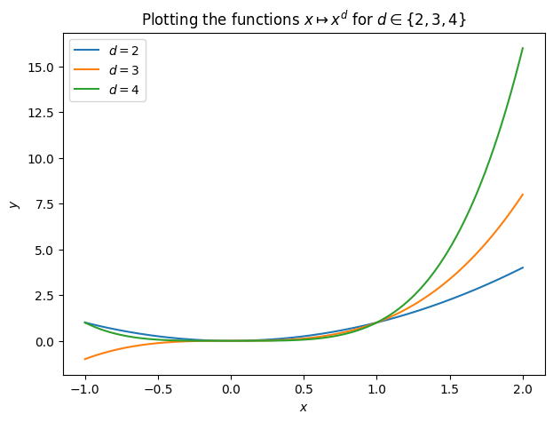

```python
n = 10_000
x = np.linspace(-1, 2, n)
list_d = [2, 3, 4]

dict_y = dict()
for d in list_d:
    dict_y[d] = x**d

plt.figure(figsize=(7, 5))
for d in list_d:
    plt.plot(x, dict_y[d], label=f"$d = {d}$")
plt.title("Plotting the functions $x \mapsto x^d$ for $d \in \{2, 3, 4\}$")
plt.xlabel("$x$")
plt.ylabel("$y$")
plt.legend()
plt.show()
```

As the figures are often exported, they must be self-contained (contain by itself all the information needed to understand what is in the plot).

# Bonus : Numpy broadcasting

## Question 15

```python
arr = np.arange(1, 19+1, step=2)
print(arr)
```

```
[ 1  3  5  7  9 11 13 15 17 19]
```

```python
arr = arr - np.mean(arr)
print(arr)
```

```
[-9. -7. -5. -3. -1.  1.  3.  5.  7.  9.]
```

```python
M = np.arange(12).reshape(3, 4)
print(M)
```

```
[[ 0  1  2  3]
 [ 4  5  6  7]
 [ 8  9 10 11]]
```

## Question 16

```python
M - np.mean(M, axis=0)
```

```
array([[-4., -4., -4., -4.],
       [ 0.,  0.,  0.,  0.],
       [ 4.,  4.,  4.,  4.]])
```

```python
M - np.mean(M, axis=1)[:, None]
```

```
array([[-1.5, -0.5,  0.5,  1.5],
       [-1.5, -0.5,  0.5,  1.5],
       [-1.5, -0.5,  0.5,  1.5]])
```

## Question 17

```python
np.arange(5) * np.arange(3)[:, None]
```

```
array([[0, 0, 0, 0, 0],
       [0, 1, 2, 3, 4],
       [0, 2, 4, 6, 8]])
```

# Bonus : value and reference types

Just a draft for now

```python
a = 256
b = 256
print(id(a))
print(id(b))
print(f"{a == b}")
print(f"{a is b}")
```

```
140676016939216
140676016939216
True
True
```

```python
a = 257
b = 257
print(id(a))
print(id(b))
print(f"{a == b}")
print(f"{a is b}")
```

```
140674679608592
140674679608880
True
False
```

Don't use `is` to test integers!